# Guitar string tension

### Derived formulas

- String tension: $F = \mu . \lambda^2 . {f}^2$
- String diameter: $d = \frac{\sqrt {F}}{\sqrt {\pi\rho}.{L}.{f}}$

### Constants

Having a tuning reference A of 440 Hz, the frequency for each guitar string is:

| string | E (low) | A | D | G | B | E (high) |
| --- | --- | --- | --- | --- | --- | --- |
| number | 6 | 5 | 4 | 3 | 2 | 1 |
| frequency (Hz) | 82.41 | 110.00 | 146.83 | 196.00 | 246.94 | 329.63 |

Density of string material most often seen on classical guitars. Required when calculating mass per unit length:

| material | density [kg/m$^3$] |
| --- | --- |
| carbon | 1790 |
| gut | 1360 |
| nylon | 1140 |

The exact density may vary per manufacturer and can depend on the material species.

- Wave length is based on the speed of sound: 340.29 m/s
- Standard gravity 9.80665 m/s$^2$
- scale length (in this notebook) 25,5 in = 0.6477 m

#### Conversions

It might be necessary to convert between the US customary units system (imperial) and the Système international (metric). This table lists the most frequently used units in string calculation:

| unit | U.S. customary units | metric SI |
| --- | --- | --- |
| length | 1 in | 0.0254 m |
| mass | 1 lb | 0.45359237 kg |
| mass/unit length | 1 lb/in | 17.8579673 kg/m |
| density | 1 lb/ft$^3$ | 16.01846337396 kg/m$^3$ |
| tension | 1 lb (actually lbf) | 4.4482216153 N |

# String calculations

Examples of possible string calculations:

- string tension based on calculated $\mu$
- string tension based on manufacturer provided $\mu$
- frequency open strings
- diameter string
- string tension note D on string E (low) and note F# on string G

```python
import math
import pandas as pd
import seaborn as sns
import matplotlib.pyplot as plt
from IPython.display import Image
```

## Read in data

Read data of the following D'Addario string sets I use on my guitars:

- EJ45 Normal Tension (twice due to recalculated string tensions by D'Addario)
- EJ46 Hard Tension
- EJ44 Extra Hard Tension

The [D'Addario Tension Guide](http://www.daddario.com/upload/tension_chart_13934.pdf) is used to get the mass per unit length (unit-weight). All units of measurement are based on the US customary units system (imperial).

```python
df = pd.read_csv('data/daddariostrings.csv')
df.head()
```

|  | string | number | diameter | tension | unit-weight | description |
| --- | --- | --- | --- | --- | --- | --- |
| 0 | E | 1 | 0.0280 | 15.3 | 0.000021 | EJ45 |
| 1 | B | 2 | 0.0322 | 11.6 | 0.000028 | EJ45 |
| 2 | G | 3 | 0.0403 | 12.1 | 0.000047 | EJ45 |
| 3 | D | 4 | 0.0290 | 15.6 | 0.000108 | EJ45 |
| 4 | A | 5 | 0.0350 | 15.0 | 0.000184 | EJ45 |

```python
# constants
stringFreqDict = {1 : 329.63, 2 : 246.94, 3 : 196.00, 4: 146.83, 5 : 110.00, 6: 82.41}
rho_nylon = 1140.0
scale_length = 0.6477
gravity = 9.80665
```

```python
def convert2metric(row):
    row['diameter'] = row['diameter'] * 0.0254
    row['tension'] = row['tension'] * 4.4482216153
    row['unit-weight'] = row['unit-weight'] * 17.8579673
    return row
```

```python
def tensionProvidedMu(string, freq = 'open'):
    return string['unit-weight'] * pow(2 * scale_length, 2) * pow(stringFreqDict[string['number']] if freq == 'open' else freq, 2)
```

```python
def tensionCalculateMu(string, freq = 'open'):
    mu = math.pi * pow(0.5 * string['diameter'], 2) * rho_nylon
    return mu * pow(2 * scale_length, 2) * pow(stringFreqDict[string['number']] if freq == 'open' else freq, 2)
```

```python
def calculatePitch(string):
    return 1 / (2 * scale_length) * math.sqrt((string['tension']) / string['unit-weight'])
```

```python
def calculateDiameter(string, freq = 'open'):
    return math.sqrt(string['tension']) / (math.sqrt(math.pi * rho_nylon) * scale_length * (stringFreqDict[string['number']] if freq == 'open' else freq))
```

### Tension calculations

```python
# Results calculations stored in
strings = []
tensions = []
tensionsC = []
types= []
pitches = []
diams = []
dash = '-' * 78
print(dash)
print('{:<10s}{:<8s}{:>20s}{:>20s}{:>20s}'.format('String', 'Type','Tension [N]','Pitch [Hz]','Diameter [mm]'))
print(dash)
for index, row in df.iterrows():
    string = convert2metric(row)
    strings.append(string['string'] + '(' + str(string['number']) + ')')
    types.append(string['description'])
    tension = tensionProvidedMu(string)
    tensions.append(tension)
    tensionsC.append(tensionCalculateMu(string))
    pitch = calculatePitch(string)
    pitches.append(pitch)
    diameter = calculateDiameter(string) * 1000.0 #in mm
    diams.append(diameter)
    print('{:<10s}{:<8s}{:>20.6f}{:>20.6f}{:>20.6f}'.format(string['string'] + '(' + str(string['number']) + ')', string['description'],tension,pitch,diameter))
string_data = {'String' : strings, 'Type' : types, 'Tension [N]' : tensions, 'Pitch [Hz]' : pitches, 'Diameter [mm]' : diams}
dfTension = pd.DataFrame(string_data, columns = ['String', 'Type', 'Tension [N]', 'Pitch [Hz]', 'Diameter [mm]'])
```

```
------------------------------------------------------------------------------
String    Type             Tension [N]          Pitch [Hz]       Diameter [mm]
------------------------------------------------------------------------------
E(1)      EJ45               68.116912          329.486920            0.645670
B(2)      EJ45               51.659299          246.796726            0.750463
G(3)      EJ45               53.864793          195.924824            0.965670
D(4)      EJ45               69.476741          146.740700            1.463657
A(5)      EJ45               66.776013          109.956594            1.915777
E(6)      EJ45               62.341176           82.366317            2.470450
E(1)      EJ45-New           68.116912          339.353024            0.665004
B(2)      EJ45-New           51.659299          251.433791            0.764564
G(3)      EJ45-New           53.864793          194.135519            0.956851
D(4)      EJ45-New           69.476741          146.834735            1.464595
A(5)      EJ45-New           66.776013          113.171637            1.971793
E(6)      EJ45-New           62.341176           82.923347            2.487157
E(1)      EJ46               70.363598          339.805009            0.676782
B(2)      EJ46               53.431832          251.099251            0.776535
G(3)      EJ46               55.200189          195.133374            0.973618
D(4)      EJ46               72.597186          146.467452            1.493379
A(5)      EJ46               70.782719          113.562566            2.037099
E(6)      EJ46               64.567647           84.358772            2.574996
E(1)      EJ44               73.033572          339.436118            0.688755
B(2)      EJ44               55.661204          250.533777            0.790785
G(3)      EJ44               57.433523          194.081171            0.987763
D(4)      EJ44               72.597186          146.467452            1.493379
A(5)      EJ44               70.782719          113.562566            2.037099
E(6)      EJ44               69.909955           82.262043            2.612811
```

```python
string_data['Tension [N]'] = tensionsC
dfTensionC = pd.DataFrame(string_data, columns = ['String', 'Type', 'Tension [N]', 'Pitch'])
```

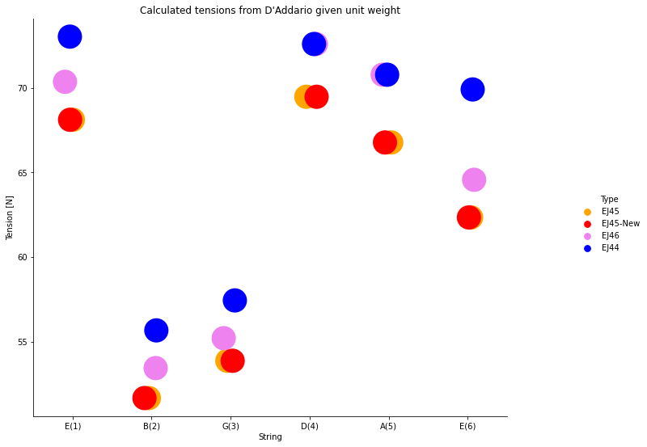

```python
my_colours = ['orange', 'red', 'violet', 'blue' ]# Set your custom colour palette
sns.set_palette(sns.color_palette(my_colours))
g = sns.catplot(x='String', y='Tension [N]', data=dfTension, hue='Type', s = 30)
g.fig.set_figwidth(12)
g.fig.set_figheight(8)
plt.title("Calculated tensions from D'Addario given unit weight")
```

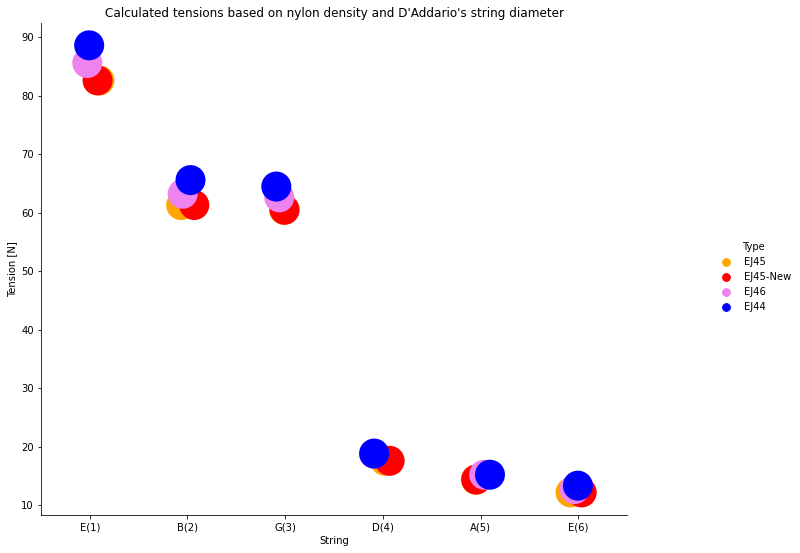

```python
my_colours = ['orange', 'red', 'violet', 'blue' ]
sns.set_palette(sns.color_palette(my_colours))
g = sns.catplot(x='String', y='Tension [N]', data=dfTensionC, hue='Type', s = 30)
g.fig.set_figwidth(12)
g.fig.set_figheight(8)
plt.title("Calculated tensions based on nylon density and D'Addario's string diameter")
```

- for all types the three bass strings have extremely low tensions. This is probably due to the diameter on the D'Addario string set packaging which is **not** the silverplated wound diameter but rather that of the nylon core.
- the nylon density value $\rho$ might be different from the exact one.

### Frequency calculation

Based on manufacturer provided mass per unit length (unit-weight) and tension.

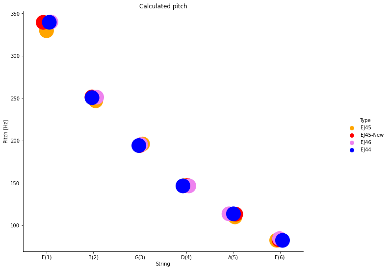

```python
my_colours = ['orange', 'red', 'violet', 'blue' ]
sns.set_palette(sns.color_palette(my_colours))
g = sns.catplot(x='String', y='Pitch [Hz]', data=dfTension, hue='Type', s = 30)
g.fig.set_figwidth(12)
g.fig.set_figheight(8)
plt.title("Calculated pitch")
```

- see printed table above for the calculated values
- as expected bass strings have lower frequencies
- especially for string E(1) the frequencies are about 10 Hz higher than the given 329.63 Hz for this string. This is caused by a higher tension in the `daddariostrings.csv` file (mentioned on string set packaging and website) in comparison with the tensions in D'Addario's Tension Guide. Unit weight $\mu$ is taken from this Tension Guide.

### Diameter calculation

Diameter in calculation converted to mm.

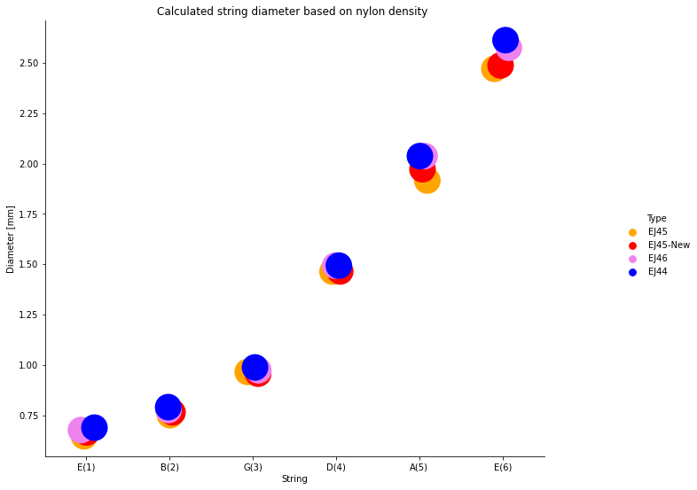

```python
my_colours = ['orange', 'red', 'violet', 'blue' ]
sns.set_palette(sns.color_palette(my_colours))
g = sns.catplot(x='String', y='Diameter [mm]', data=dfTension, hue='Type', s = 30)
g.fig.set_figwidth(12)
g.fig.set_figheight(8)
plt.title("Calculated string diameter based on nylon density ")
```

- see printed table above for the calculated values
- bass strings are thicker than the treble strings.
- calculated treble string diameters differ a bit from those listed by D'Addario. Probably caused by other nylon density value.
- calculated bass string diameters are significantly larger than given on D'Addario's string set packaging and website. Pretty sure the manufacturer provided figures are without the wrap material (silver-plated copper).

### Tension for specific notes

- E(6) tuning to D gives it a 73.416 Hz pitch
- G(3) to F# gives a 184.997 Hz pitch

```python
dash = '-' * 58
print(dash)
print('{:<10s}{:<8s}{:>20s}{:>20s}'.format('String', 'Type','Pitch [Hz]','Tension [N]'))
print(dash)
for index,row in df.iterrows():
    if row.string=='G' or (row.string=='E' and row.number==6):
        string = convert2metric(row)
        print('{:<10s}{:<8s}{:>20.6f}{:>20.6f}'.format(string['string'] + '(' + str(string['number']) + ')', string['description'],stringFreqDict[string['number']],tensionProvidedMu(string)))
        pitch = 184.997 if row.string=='G' else 73.416
        print('{:<10s}{:<8s}{:>20.6f}{:>20.6f}'.format(string['string'] + '(' + str(string['number']) + ')', string['description'],pitch,tensionProvidedMu(string, pitch)))
```

```
----------------------------------------------------------
String    Type              Pitch [Hz]         Tension [N]
----------------------------------------------------------
G(3)      EJ45              196.000000           53.864793
G(3)      EJ45              184.997000           47.986848
E(6)      EJ45               82.410000           62.341176
E(6)      EJ45               73.416000           49.476230
G(3)      EJ45-New          196.000000           53.864793
G(3)      EJ45-New          184.997000           47.986848
E(6)      EJ45-New           82.410000           62.341176
E(6)      EJ45-New           73.416000           49.476230
G(3)      EJ46              196.000000           55.200189
G(3)      EJ46              184.997000           49.176520
E(6)      EJ46               82.410000           64.567647
E(6)      EJ46               73.416000           51.243238
G(3)      EJ44              196.000000           57.433523
G(3)      EJ44              184.997000           51.166143
E(6)      EJ44               82.410000           69.909955
E(6)      EJ44               73.416000           55.483089
```